# Group 3 Task 2

Nzambuli Daniel & Waimiri Romeo

2024-07-10

## The data

```r
library(readxl)
library(dplyr)
library(stringr)
Patient_Data <- read_excel("Task2_data.xlsx")
head(Patient_Data)
```

```
## # A tibble: 6 × 135
##    S.no Code  Facility_Type Sex_Patient   Age Date_Started
##   <dbl> <chr> <chr>         <chr>       <dbl> <dttm>
## 1     1 LM001 Home-care     Female         79 2024-04-16 00:00:00
## 2     2 LM002 Home-care     Female         88 2022-12-06 00:00:00
## 3     3 LM003 Home-care     Female         84 2024-01-29 00:00:00
## 4     4 MT001 Home-care     Female         82 2024-04-01 00:00:00
## 5     5 MT002 Home-care     Male           75 2024-04-01 00:00:00
## 6     6 MT003 Home-care     Female         88 2024-03-01 00:00:00
## # ℹ 129 more variables: Date_Ended <dttm>, ...8 <chr>, Education <chr>,
## #   Race <chr>, Marital <chr>, Length_Separated <chr>, Household_Patient <chr>,
## #   Household_below5 <dbl>, `Household_5-18` <dbl>, Household_above18 <chr>,
## #   Level_Dependancy <chr>, Current_Condition...18 <chr>, Alcohol <chr>,
## #   Physical_Activities <chr>, Smoking <chr>, Processed_Food <chr>,
## #   Rate_Nusingcare <chr>, Rate_Medication <chr>, Meals <chr>,
## #   Infrastructure <chr>, Rate_Accessibility <chr>, Rate_Physiotherapy <chr>, …
```

# Bar chart(%) patient highest Completed Education Level

```r
Education_data = as.data.frame(table(Patient_Data$Client_Education))
Education_data
```

```
##                   Var1 Freq
## 1             Bachelor   83
## 2              Masters   34
## 3 Not completed formal    2
## 4                  PhD    7
## 5    Prefer not to say    6
## 6              Primary    2
## 7            Secondary   13
## 8           Vocational   38
```

### Convert the data to percentages

```r
Education_data$percentage = Education_data$Freq/ sum(Education_data$Freq) * 100
Education_data
```

```
##                   Var1 Freq percentage
## 1             Bachelor   83  44.864865
## 2              Masters   34  18.378378
## 3 Not completed formal    2   1.081081
## 4                  PhD    7   3.783784
## 5    Prefer not to say    6   3.243243
## 6              Primary    2   1.081081
## 7            Secondary   13   7.027027
## 8           Vocational   38  20.540541
```

```r
colnames(Education_data) = c("Level_of_Edu", "No_Patients", "Percentage_Patients")
Education_data = Education_data[order(Education_data$Percentage_Patients),]
Education_data
```

```
##           Level_of_Edu No_Patients Percentage_Patients
## 3 Not completed formal           2            1.081081
## 6              Primary           2            1.081081
## 5    Prefer not to say           6            3.243243
## 4                  PhD           7            3.783784
## 7            Secondary          13            7.027027
## 2              Masters          34           18.378378
## 8           Vocational          38           20.540541
## 1             Bachelor          83           44.864865
```

### Plot the bargraph

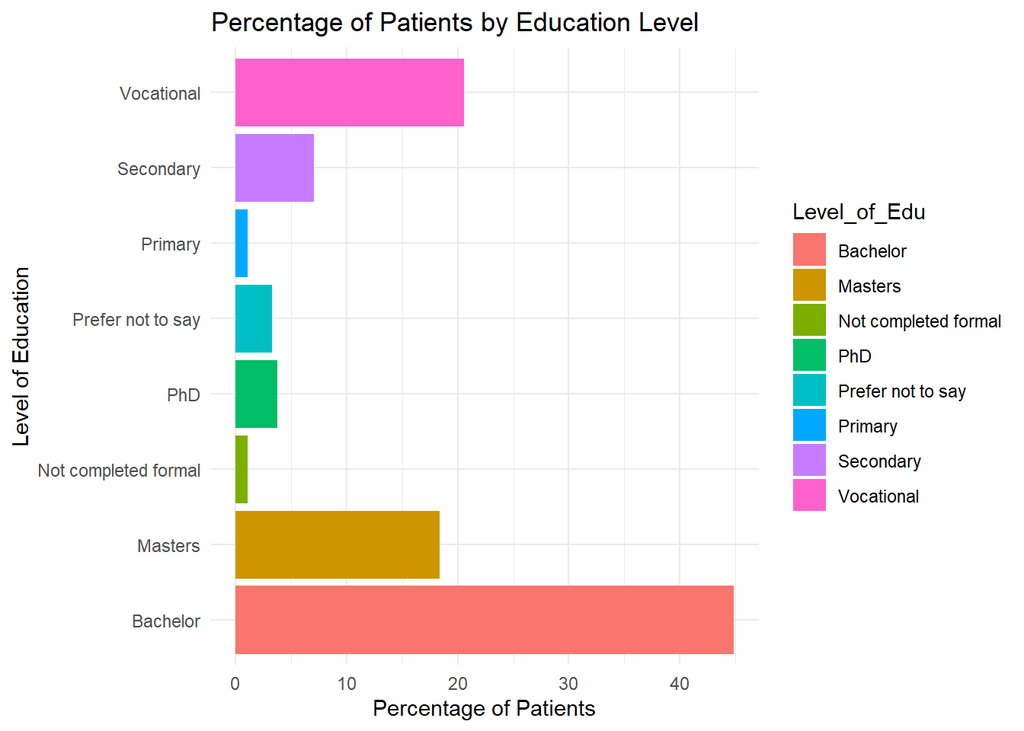

```r
library(ggplot2)
ggplot(Education_data, aes(x = Level_of_Edu, y = Percentage_Patients, fill = Level_of_Edu)) +
  geom_bar(stat = "identity") +
  coord_flip()+
  labs(x = "Level of Education", y = "Percentage of Patients", title = "Percentage of Patients by Education Level") +
  scale_y_continuous(breaks = seq(0, 100, 10)) +
  theme_minimal()
```

### Plotting function

```r
create_frequency_bar_graphs = function(data, x_col, y_col){
  y_lab = y_col
  x_lab =  x_col
  ttl = paste(y_lab, "by", x_lab)
  ggplot(data, aes_string(x = x_col, y = y_col, fill = x_col)) +
  geom_bar(stat = "identity") +
  coord_flip()+
  labs(x = x_lab, y = y_lab, title = ttl) +
  theme_minimal()
}


create_percentage_bar_graphs = function(data, x_col, y_col){
  y_lab = y_col
  x_lab = x_col
  ttl = paste(y_lab, "by", x_lab)
  ggplot(data, aes_string(x = x_col, y = y_col, fill = x_col)) +
  geom_bar(stat = "identity") +
  coord_flip()+
  labs(x = x_lab, y = y_lab, title = ttl) +
  scale_y_continuous(breaks = seq(0, 100, 10)) + #, labels = scales::percent
  theme_minimal()
}
```

### Education by Home Care

```r
Home_Care_Edu = Patient_Data %>%
  filter(Facility_Type == "Home-care") %>%
  .$Client_Education %>%
  table() %>%
  as.data.frame()

Home_Care_Edu$Percentage = Home_Care_Edu$Freq / sum(Home_Care_Edu$Freq) * 100
names(Home_Care_Edu) = c("Level_of_Edu", "No_Patients", "Perc_HomeCare_Patients")
Home_Care_Edu
```

```
##           Level_of_Edu No_Patients Perc_HomeCare_Patients
## 1             Bachelor          76              45.783133
## 2              Masters          29              17.469880
## 3 Not completed formal           2               1.204819
## 4                  PhD           7               4.216867
## 5    Prefer not to say           6               3.614458
## 6              Primary           2               1.204819
## 7            Secondary          12               7.228916
## 8           Vocational          32              19.277108
```

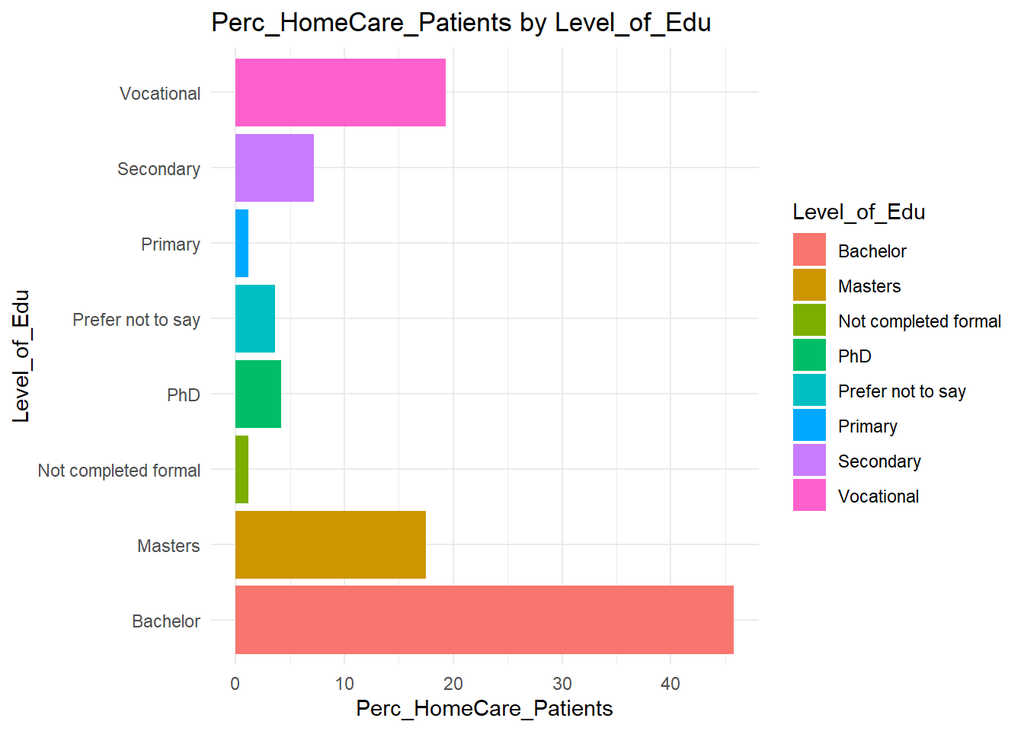

```r
create_percentage_bar_graphs(Home_Care_Edu, "Level_of_Edu", "Perc_HomeCare_Patients")
```

### Education by in-patient

```r
In_patient_Edu = Patient_Data %>%
  filter(Facility_Type == "Inpatient") %>%
  .$Client_Education %>%
  table() %>%
  as.data.frame()

In_patient_Edu$Percentage = In_patient_Edu$Freq / sum(In_patient_Edu$Freq) * 100
names(In_patient_Edu) = c("Level_of_Edu", "No_Patients", "Perc_InPatient_Patients")
In_patient_Edu
```

```
##   Level_of_Edu No_Patients Perc_InPatient_Patients
## 1     Bachelor           7               36.842105
## 2      Masters           5               26.315789
## 3    Secondary           1                5.263158
## 4   Vocational           6               31.578947
```

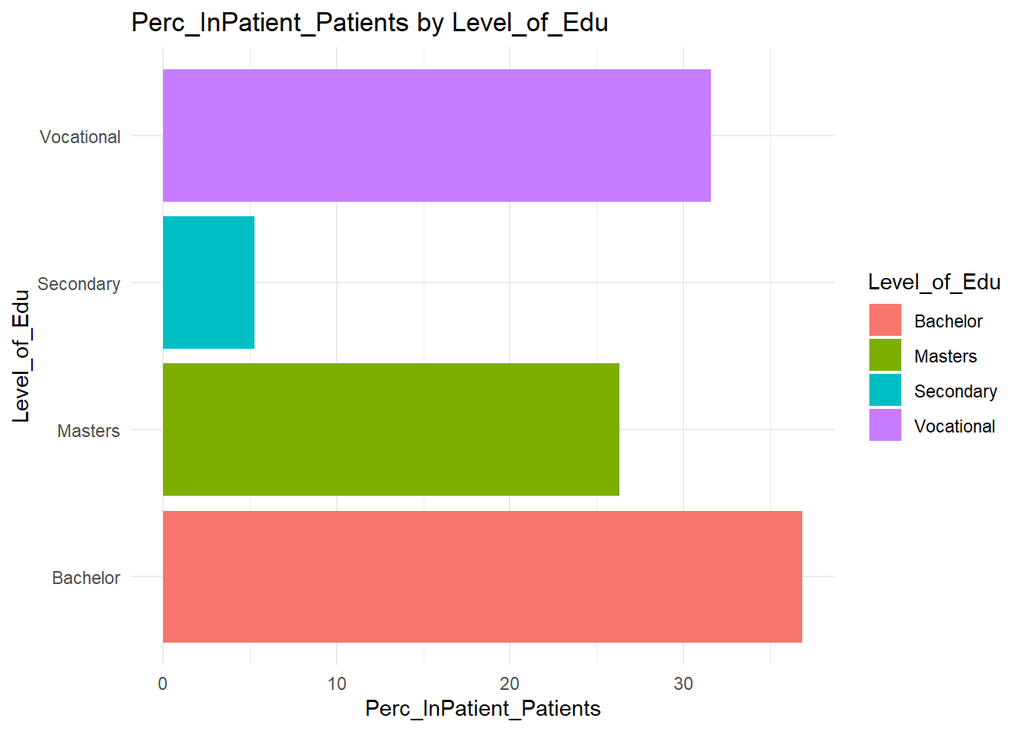

```r
create_percentage_bar_graphs(In_patient_Edu, "Level_of_Edu", "Perc_InPatient_Patients")
```

# Univariate cox regression for patient

```r
library(survival)
cox_regression = function(data, response){
  form = as.formula(paste("Surv(duration, event_observed) ~", response))
  rex_cox =  coxph(formula = form, data = data)
  return(summary(rex_cox))
}
```

## 1. highest completed education level with categories 0-6

### Create columns of level of education

```r
as.character(Education_data$Level_of_Edu)
```

```
## [1] "Not completed formal" "Primary"              "Prefer not to say"
## [4] "PhD"                  "Secondary"            "Masters"
## [7] "Vocational"           "Bachelor"
```

### Confirm if the values are in the original data set columns

```r
as.character(Education_data$Level_of_Edu) %in% colnames(Patient_Data)
```

```
## [1] FALSE FALSE FALSE FALSE FALSE FALSE FALSE FALSE
```

### Make columns of 1 and 0

```r
create_indicator_column <- function(data, column_name, match_value, new_column_name) {
  data <- data %>%
    mutate(!!new_column_name := if_else(!!sym(column_name) == match_value, 1, 0))

  return(data)
}
```

### New columns

```r
columns_to_make = as.character(Education_data$Level_of_Edu)
for(column in columns_to_make){
  Patient_Data = create_indicator_column(Patient_Data, "Client_Education", column, column)
}
```

### Confirm

```r
Patient_Data$Secondary
```

```
##   [1]  0  0  0  1  0  0  0  1  0  1  0  0  0  0  0  0  0  0  0  0  0  0  1  1  0
##  [26]  0  0  1  1  0  0  1  0  0  0  0  0  0  0  0  0  0  0  0  0  0  0  0  0  0
##  [51]  0  0  0  0 NA  0  0  0  1  0  0  0  0  0  0  0  0  0  0  0  0  0  0  0  0
##  [76]  0  0  0  0  0  0  0  0  0  0  0  0  0  0  0  0  0  0  0  0  0  0  0  0  0
## [101]  0  0  0  0  0  0  0  1  1  1  0  0  0  0  0  0  0  0  0  0  0  0  0  0  0
## [126]  0  0  0  0  0  0  0  0  0  0  0  0  0  0  0  0  0  0  0  0  0  0  0  0  0
## [151]  0  0  0  0  0  0  0  0  0  0  0  0  0  0  0  1  0  0  0  0  0  0  0  0 NA
## [176]  0  0  0  0  0  0  0  0  0  0  0  0
```

## All Data set coxph

```r
names(Patient_Data) = sapply(names(Patient_Data), function(name) {
  if (name %in% columns_to_make) {

    gsub(" ", "_", name)
  } else {
    name
  }
})
```

```r
interested = gsub(" ", "_", columns_to_make)
for (column in interested){
  print(paste("cox regression for: ", column))
  cat("\n\n\n")
  print(cox_regression(Patient_Data, column))
  cat("\n\n\n")
}
```

```
## [1] "cox regression for:  Not_completed_formal"
##
##
##
## Call:
## coxph(formula = form, data = data)
##
##   n= 185, number of events= 56
##    (2 observations deleted due to missingness)
##
##                       coef exp(coef) se(coef)     z Pr(>|z|)
## Not_completed_formal 1.413     4.108    1.023 1.382    0.167
##
##                      exp(coef) exp(-coef) lower .95 upper .95
## Not_completed_formal     4.108     0.2434    0.5536     30.49
##
## Concordance= 0.508  (se = 0.009 )
## Likelihood ratio test= 1.29  on 1 df,   p=0.3
## Wald test            = 1.91  on 1 df,   p=0.2
## Score (logrank) test = 2.25  on 1 df,   p=0.1
##
##
##
##
## [1] "cox regression for:  Primary"
```

```
## Call:
## coxph(formula = form, data = data)
##
##   n= 185, number of events= 56
##    (2 observations deleted due to missingness)
##
##               coef  exp(coef)   se(coef)      z Pr(>|z|)
## Primary -1.602e+01  1.106e-07  4.197e+03 -0.004    0.997
##
##         exp(coef) exp(-coef) lower .95 upper .95
## Primary 1.106e-07    9044515         0       Inf
##
## Concordance= 0.505  (se = 0.004 )
## Likelihood ratio test= 1.02  on 1 df,   p=0.3
## Wald test            = 0  on 1 df,   p=1
## Score (logrank) test = 0.51  on 1 df,   p=0.5
##
##
##
##
## [1] "cox regression for:  Prefer_not_to_say"
##
##
##
## Call:
## coxph(formula = form, data = data)
##
##   n= 185, number of events= 56
##    (2 observations deleted due to missingness)
##
##                     coef exp(coef) se(coef)     z Pr(>|z|)
## Prefer_not_to_say 0.4760    1.6097   0.5999 0.794    0.427
##
##                   exp(coef) exp(-coef) lower .95 upper .95
## Prefer_not_to_say      1.61     0.6213    0.4967     5.216
##
## Concordance= 0.512  (se = 0.017 )
## Likelihood ratio test= 0.55  on 1 df,   p=0.5
## Wald test            = 0.63  on 1 df,   p=0.4
## Score (logrank) test = 0.64  on 1 df,   p=0.4
```

[output cut: 107 more lines]

```
## coxph(formula = form, data = data)
##
##   n= 185, number of events= 56
##    (2 observations deleted due to missingness)
##
##             coef exp(coef) se(coef)      z Pr(>|z|)
## Bachelor -0.2962    0.7436   0.2780 -1.065    0.287
##
##          exp(coef) exp(-coef) lower .95 upper .95
## Bachelor    0.7436      1.345    0.4312     1.282
##
## Concordance= 0.54  (se = 0.035 )
## Likelihood ratio test= 1.16  on 1 df,   p=0.3
## Wald test            = 1.14  on 1 df,   p=0.3
## Score (logrank) test = 1.14  on 1 df,   p=0.3
```

## Home-stay coxph

```r
for (column in interested){
  filtered_data = Patient_Data %>% filter(Facility_Type != "Inpatient")
  print(paste("Home-stay cox regression for: ", column))
  cat("\n\n\n")
  print(cox_regression(filtered_data, column))
  cat("\n\n\n")
}
```

```
## [1] "Home-stay cox regression for:  Not_completed_formal"
##
##
##
## Call:
## coxph(formula = form, data = data)
##
##   n= 166, number of events= 45
##    (1 observation deleted due to missingness)
##
##                       coef exp(coef) se(coef)     z Pr(>|z|)
## Not_completed_formal 1.435     4.201    1.026 1.399    0.162
##
##                      exp(coef) exp(-coef) lower .95 upper .95
## Not_completed_formal     4.201     0.2381    0.5624     31.38
##
## Concordance= 0.509  (se = 0.011 )
## Likelihood ratio test= 1.32  on 1 df,   p=0.3
## Wald test            = 1.96  on 1 df,   p=0.2
## Score (logrank) test = 2.32  on 1 df,   p=0.1
##
##
##
##
## [1] "Home-stay cox regression for:  Primary"
```

```
## Call:
## coxph(formula = form, data = data)
##
##   n= 166, number of events= 45
##    (1 observation deleted due to missingness)
##
##               coef  exp(coef)   se(coef)      z Pr(>|z|)
## Primary -1.602e+01  1.104e-07  4.483e+03 -0.004    0.997
##
##         exp(coef) exp(-coef) lower .95 upper .95
## Primary 1.104e-07    9054812         0       Inf
##
## Concordance= 0.505  (se = 0.004 )
## Likelihood ratio test= 0.9  on 1 df,   p=0.3
## Wald test            = 0  on 1 df,   p=1
## Score (logrank) test = 0.45  on 1 df,   p=0.5
##
##
##
##
## [1] "Home-stay cox regression for:  Prefer_not_to_say"
##
##
##
## Call:
## coxph(formula = form, data = data)
##
##   n= 166, number of events= 45
##    (1 observation deleted due to missingness)
##
##                     coef exp(coef) se(coef)     z Pr(>|z|)
## Prefer_not_to_say 0.6206    1.8601   0.6054 1.025    0.305
##
##                   exp(coef) exp(-coef) lower .95 upper .95
## Prefer_not_to_say      1.86     0.5376    0.5678     6.093
##
## Concordance= 0.516  (se = 0.021 )
## Likelihood ratio test= 0.89  on 1 df,   p=0.3
## Wald test            = 1.05  on 1 df,   p=0.3
## Score (logrank) test = 1.08  on 1 df,   p=0.3
```

[output cut: 107 more lines]

```
## coxph(formula = form, data = data)
##
##   n= 166, number of events= 45
##    (1 observation deleted due to missingness)
##
##              coef exp(coef) se(coef)      z Pr(>|z|)
## Bachelor -0.09175   0.91233  0.30507 -0.301    0.764
##
##          exp(coef) exp(-coef) lower .95 upper .95
## Bachelor    0.9123      1.096    0.5017     1.659
##
## Concordance= 0.517  (se = 0.04 )
## Likelihood ratio test= 0.09  on 1 df,   p=0.8
## Wald test            = 0.09  on 1 df,   p=0.8
## Score (logrank) test = 0.09  on 1 df,   p=0.8
```

## In-patient coxph

```r
for (column in interested){
  filtered_data = Patient_Data %>% filter(Facility_Type == "Inpatient")
  print(paste("Inpatient cox regression for: ", column))
  cat("\n\n\n")
  print(cox_regression(filtered_data, column))
  cat("\n\n\n")
}
```

```
## [1] "Inpatient cox regression for:  Not_completed_formal"
##
##
##
## Call:
## coxph(formula = form, data = data)
##
##   n= 19, number of events= 11
##    (1 observation deleted due to missingness)
##
##                      coef exp(coef) se(coef)  z Pr(>|z|)
## Not_completed_formal   NA        NA        0 NA       NA
##
##                      exp(coef) exp(-coef) lower .95 upper .95
## Not_completed_formal        NA         NA        NA        NA
##
## Concordance= 0.5  (se = 0 )
## Likelihood ratio test= 0  on 0 df,   p=1
## Wald test            = NA  on 0 df,   p=NA
## Score (logrank) test = 0  on 0 df,   p=1
##
##
##
##
## [1] "Inpatient cox regression for:  Primary"
##
##
##
## Call:
## coxph(formula = form, data = data)
##
##   n= 19, number of events= 11
##    (1 observation deleted due to missingness)
##
##         coef exp(coef) se(coef)  z Pr(>|z|)
## Primary   NA        NA        0 NA       NA
##
##         exp(coef) exp(-coef) lower .95 upper .95
## Primary        NA         NA        NA        NA
##
```

[output cut: 135 more lines]

```
## coxph(formula = form, data = data)
##
##   n= 19, number of events= 11
##    (1 observation deleted due to missingness)
##
##             coef exp(coef) se(coef)      z Pr(>|z|)
## Bachelor -1.1547    0.3152   0.7852 -1.471    0.141
##
##          exp(coef) exp(-coef) lower .95 upper .95
## Bachelor    0.3152      3.173   0.06763     1.469
##
## Concordance= 0.65  (se = 0.068 )
## Likelihood ratio test= 2.67  on 1 df,   p=0.1
## Wald test            = 2.16  on 1 df,   p=0.1
## Score (logrank) test = 2.41  on 1 df,   p=0.1
```

## 2. How long have you been separated [0-4]

in the column `Length_Separated`

```r
as.data.frame(table(Patient_Data$Length_Separated))
```

```
##                Var1 Freq
## 1               <6m    4
## 2                >5   52
## 3           >50,000    1
## 4               1<3   14
## 5               3<5   28
## 6 More than 5 years    4
## 7                NA    1
```

### Correct values

> Expected values
> - last six months
> - more than six(6) months but less than one(1) year
> - 1 year - below 3 years
> - 3 years - below 5 years
> - more than 5 years

```r
Patient_Data = Patient_Data %>%
  mutate(Length_Separated = str_replace_all(Length_Separated, ">50,000", ">5"),
         Length_Separated = ifelse(Length_Separated == "NA", NA, Length_Separated)
         )
```

### confirm

```r
as.data.frame(table(Patient_Data$Length_Separated))
```

```
##                Var1 Freq
## 1               <6m    4
## 2                >5   53
## 3               1<3   14
## 4               3<5   28
## 5 More than 5 years    4
```

### Coxph data

```r
Patient_Data = Patient_Data %>%
  mutate(Length_Separated = ifelse(Length_Separated %in% c("<6m", ">5", "1<3", "3<5"), "Others", Length_Separated))
Patient_Data = create_indicator_column(Patient_Data, "Length_Separated", "Others", "Separated_more_than_4yrs")
```

### Confirm

```r
Patient_Data$Separated_more_than_4yrs
```

```
##   [1]  0  0  0 NA NA  0 NA NA NA NA  1  1  1 NA NA NA NA  1 NA NA  1  1  1 NA  1
##  [26]  1  1  1  1  1  1 NA NA NA NA NA NA  1 NA  1 NA  1  1 NA  1  1 NA NA NA NA
##  [51]  1  1  1  1 NA NA  1  1 NA NA  1  1  1  1  1  1  1  1 NA  1  1 NA NA  1  1
##  [76] NA NA NA NA  1  1 NA NA  1 NA  1  1  1  1  1  1  1 NA  1  1 NA  1 NA  1 NA
## [101]  1  1 NA  1  1  1  1 NA  1 NA  1 NA  1  1  1 NA NA NA  1 NA NA  1 NA  1  1
## [126] NA NA NA  1  1  1  1 NA NA NA NA NA NA NA NA  1 NA  1  1 NA NA NA  1  1  1
## [151] NA  1  1  1  1  1  1 NA  1 NA NA  1  1  1  1 NA  1 NA  1  1  1  1  1 NA  1
## [176] NA NA NA  1 NA  1 NA  1 NA NA  1 NA
```

## All Data set coxph

```r
print(paste("cox regression for: ", "Separated_more_than_4yrs"))
```

```
## [1] "cox regression for:  Separated_more_than_4yrs"
```

```r
cat("\n\n\n")
```

```r
print(cox_regression(Patient_Data, "Separated_more_than_4yrs"))
```

```
## Call:
## coxph(formula = form, data = data)
##
##   n= 103, number of events= 33
##    (84 observations deleted due to missingness)
##
##                               coef exp(coef)  se(coef)     z Pr(>|z|)
## Separated_more_than_4yrs 1.705e+01 2.547e+07 5.310e+03 0.003    0.997
##
##                          exp(coef) exp(-coef) lower .95 upper .95
## Separated_more_than_4yrs  25469810  3.926e-08         0       Inf
##
## Concordance= 0.516  (se = 0.009 )
## Likelihood ratio test= 1.78  on 1 df,   p=0.2
## Wald test            = 0  on 1 df,   p=1
## Score (logrank) test = 0.9  on 1 df,   p=0.3
```

## Home-stay coxph

```r
filtered_home_data = Patient_Data %>% filter(Facility_Type != "Inpatient")
print(paste("Home-stay cox regression for: ", "Separated_more_than_4yrs"))
```

```
## [1] "Home-stay cox regression for:  Separated_more_than_4yrs"
```

```r
cat("\n\n\n")
```

```r
print(cox_regression(filtered_home_data, "Separated_more_than_4yrs"))
```

```
## Call:
## coxph(formula = form, data = data)
##
##   n= 90, number of events= 27
##    (77 observations deleted due to missingness)
##
##                               coef exp(coef)  se(coef)     z Pr(>|z|)
## Separated_more_than_4yrs 1.706e+01 2.569e+07 5.557e+03 0.003    0.998
##
##                          exp(coef) exp(-coef) lower .95 upper .95
## Separated_more_than_4yrs  25691802  3.892e-08         0       Inf
##
## Concordance= 0.518  (se = 0.01 )
## Likelihood ratio test= 1.63  on 1 df,   p=0.2
## Wald test            = 0  on 1 df,   p=1
## Score (logrank) test = 0.83  on 1 df,   p=0.4
```

## In-patient coxph

```r
filtered_inpatient_data = Patient_Data %>% filter(Facility_Type == "Inpatient")
print(paste(" cox regression for: ", "Separated_more_than_4yrs"))
```

```
## [1] " cox regression for:  Separated_more_than_4yrs"
```

```r
cat("\n\n\n")
```

```r
print(cox_regression(filtered_inpatient_data, "Separated_more_than_4yrs"))
```

```
## Call:
## coxph(formula = form, data = data)
##
##   n= 13, number of events= 6
##    (7 observations deleted due to missingness)
##
##                          coef exp(coef) se(coef)  z Pr(>|z|)
## Separated_more_than_4yrs   NA        NA        0 NA       NA
##
##                          exp(coef) exp(-coef) lower .95 upper .95
## Separated_more_than_4yrs        NA         NA        NA        NA
##
## Concordance= 0.5  (se = 0 )
## Likelihood ratio test= 0  on 0 df,   p=1
## Wald test            = NA  on 0 df,   p=NA
## Score (logrank) test = 0  on 0 df,   p=1
```

## 3. Alcohol consumption [not at all 0, others 1]

```r
as.data.frame(table(Patient_Data$Alcohol))
```

```
##          Var1 Freq
## 1 Less extent   39
## 2  More often   13
## 3  Not at All  109
## 4       Often   22
```

```r
sum(as.data.frame(table(Patient_Data$Alcohol))$Freq)
```

```
## [1] 183
```

### coxph data

```r
Patient_Data = Patient_Data %>%
  mutate(Alcohol = ifelse(Alcohol %in% c("Often", "More often", "Less extent"), "Others", Alcohol))
Patient_Data$Alcohol[1:10]
```

```
##  [1] "Not at All" "Not at All" "Not at All" "Not at All" "Others"
##  [6] NA           "Not at All" "Not at All" "Others"     "Not at All"
```

```r
Patient_Data = create_indicator_column(Patient_Data, "Alcohol", "Others", "No_Alcohol")
```

### Confirm

```r
Patient_Data$No_Alcohol
```

```
##   [1]  0  0  0  0  1 NA  0  0  1  0  0  0  0  0  0  0  1  0  1  0  1  0  1  1  0
##  [26]  0  0  0  1  0  0  1  1  1  1  0  0  0  1  0  0  1  0  1  0  1  1  1  1  1
##  [51]  0  0  1  1  1  0  0  0  1  1  0  0  0  1  0  0  0  0  0  0  0  0  0  1  0
##  [76]  0  0  0  0  0  0  1  1  0  1  0  1  0  0  0  0  0  0  0  1  1  0  1  0  0
## [101]  0  1  1  1  0  0  0  1  1  1  0  1  0  1  0  1  1  0  0  1  1  0  0  1  1
## [126]  0  0  0  0  1  1  0  0  0  1  0  0  0  1  1  1  0  0  1  0  1  0  0  1  0
## [151]  0  1  0  1  1  1  1  0 NA  1  1  0  0  0  1  0  0  1  1 NA  0  0  0  1  0
## [176] NA  1  0  1  0  1  0  0  1  0  1  1
```

## All Data set coxph

```r
print(paste("cox regression for: ", "No_Alcohol"))
```

```
## [1] "cox regression for:  No_Alcohol"
```

```r
cat("\n\n\n")
```

```r
print(cox_regression(Patient_Data, "No_Alcohol"))
```

```
## Call:
## coxph(formula = form, data = data)
##
##   n= 183, number of events= 55
##    (4 observations deleted due to missingness)
##
##               coef exp(coef) se(coef)      z Pr(>|z|)
## No_Alcohol -0.3030    0.7386   0.2888 -1.049    0.294
##
##            exp(coef) exp(-coef) lower .95 upper .95
## No_Alcohol    0.7386      1.354    0.4194     1.301
##
## Concordance= 0.539  (se = 0.034 )
## Likelihood ratio test= 1.13  on 1 df,   p=0.3
## Wald test            = 1.1  on 1 df,   p=0.3
## Score (logrank) test = 1.11  on 1 df,   p=0.3
```

## Home-stay coxph

```r
filtered_home_data = Patient_Data %>% filter(Facility_Type != "Inpatient")
print(paste(" cox regression for: ", "No_Alcohol"))
```

```
## [1] " cox regression for:  No_Alcohol"
```

```r
cat("\n\n\n")
```

```r
print(cox_regression(filtered_home_data, "No_Alcohol"))
```

```
## Call:
## coxph(formula = form, data = data)
##
##   n= 163, number of events= 44
##    (4 observations deleted due to missingness)
##
##               coef exp(coef) se(coef)      z Pr(>|z|)
## No_Alcohol -0.2063    0.8136   0.3156 -0.654    0.513
##
##            exp(coef) exp(-coef) lower .95 upper .95
## No_Alcohol    0.8136      1.229    0.4383      1.51
##
## Concordance= 0.54  (se = 0.038 )
## Likelihood ratio test= 0.43  on 1 df,   p=0.5
## Wald test            = 0.43  on 1 df,   p=0.5
## Score (logrank) test = 0.43  on 1 df,   p=0.5
```

## In-patient coxph

```r
filtered_inpatient_data = Patient_Data %>% filter(Facility_Type == "Inpatient")
print(paste(" cox regression for: ", "No_Alcohol"))
```

```
## [1] " cox regression for:  No_Alcohol"
```

```r
cat("\n\n\n")
```

```r
print(cox_regression(filtered_inpatient_data, "No_Alcohol"))
```

```
## Call:
## coxph(formula = form, data = data)
##
##   n= 20, number of events= 11
##
##               coef exp(coef) se(coef)     z Pr(>|z|)
## No_Alcohol -0.5419    0.5816   0.7853 -0.69     0.49
##
##            exp(coef) exp(-coef) lower .95 upper .95
## No_Alcohol    0.5816      1.719    0.1248     2.711
##
## Concordance= 0.515  (se = 0.082 )
## Likelihood ratio test= 0.53  on 1 df,   p=0.5
## Wald test            = 0.48  on 1 df,   p=0.5
## Score (logrank) test = 0.49  on 1 df,   p=0.5
```

## 4. Physical activities behavior [not at all 0, others 1]

```r
as.data.frame(table(Patient_Data$Physical_Activities))
```

```
##          Var1 Freq
## 1 Less extent   60
## 2  More often   22
## 3  Not at all   37
## 4       Often   49
```

```r
Patient_Data = Patient_Data %>%
  mutate(Physical_Activities = ifelse(Physical_Activities %in% c("Often", "More often", "Less extent"), "Others", Physical_Activities))
Patient_Data = create_indicator_column(Patient_Data, "Physical_Activities", "Others", "No_Physical_Activities")
```

## All Data set coxph

```r
print(paste("cox regression for: ", "No_Physical_Activities"))
```

```
## [1] "cox regression for:  No_Physical_Activities"
```

```r
cat("\n\n\n")
```

```r
print(cox_regression(Patient_Data, "No_Physical_Activities"))
```

```
## Call:
## coxph(formula = form, data = data)
##
##   n= 168, number of events= 50
##    (19 observations deleted due to missingness)
##
##                           coef exp(coef) se(coef)     z Pr(>|z|)
## No_Physical_Activities -0.8754    0.4167   0.3008 -2.91  0.00361 **
## ---
## Signif. codes:  0 '***' 0.001 '**' 0.01 '*' 0.05 '.' 0.1 ' ' 1
##
##                        exp(coef) exp(-coef) lower .95 upper .95
## No_Physical_Activities    0.4167        2.4    0.2311    0.7514
##
## Concordance= 0.607  (se = 0.037 )
## Likelihood ratio test= 7.58  on 1 df,   p=0.006
## Wald test            = 8.47  on 1 df,   p=0.004
## Score (logrank) test = 9.02  on 1 df,   p=0.003
```

## Home-stay coxph

```r
filtered_home_data = Patient_Data %>% filter(Facility_Type != "Inpatient")

print(paste(" cox regression for: ", "No_Physical_Activities"))
```

```
## [1] " cox regression for:  No_Physical_Activities"
```

```r
cat("\n\n\n")
```

```r
print(cox_regression(filtered_home_data, "No_Physical_Activities"))
```

```
## Call:
## coxph(formula = form, data = data)
##
##   n= 148, number of events= 39
##    (19 observations deleted due to missingness)
##
##                           coef exp(coef) se(coef)     z Pr(>|z|)
## No_Physical_Activities -0.9091    0.4029   0.3510 -2.59  0.00959 **
## ---
## Signif. codes:  0 '***' 0.001 '**' 0.01 '*' 0.05 '.' 0.1 ' ' 1
##
##                        exp(coef) exp(-coef) lower .95 upper .95
## No_Physical_Activities    0.4029      2.482    0.2025    0.8015
##
## Concordance= 0.608  (se = 0.042 )
## Likelihood ratio test= 5.89  on 1 df,   p=0.02
## Wald test            = 6.71  on 1 df,   p=0.01
## Score (logrank) test = 7.17  on 1 df,   p=0.007
```

## In-patient coxph

```r
filtered_inpatient_data = Patient_Data %>% filter(Facility_Type == "Inpatient")

print(paste(" cox regression for: ", "No_Physical_Activities"))
```

```
## [1] " cox regression for:  No_Physical_Activities"
```

```r
cat("\n\n\n")
```

```r
print(cox_regression(filtered_inpatient_data, "No_Physical_Activities"))
```

```
## Call:
## coxph(formula = form, data = data)
##
##   n= 20, number of events= 11
##
##                           coef exp(coef) se(coef)     z Pr(>|z|)
## No_Physical_Activities -0.6033    0.5470   0.6155 -0.98    0.327
##
##                        exp(coef) exp(-coef) lower .95 upper .95
## No_Physical_Activities     0.547      1.828    0.1637     1.827
##
## Concordance= 0.592  (se = 0.085 )
## Likelihood ratio test= 0.93  on 1 df,   p=0.3
## Wald test            = 0.96  on 1 df,   p=0.3
## Score (logrank) test = 0.99  on 1 df,   p=0.3
```

## 5. Smoking [not at all 0, others 1]

```r
as.data.frame(table(Patient_Data$Smoking))
```

```
##   Var1 Freq
## 1   No  138
## 2  Yes   33
```

```r
Patient_Data = create_indicator_column(Patient_Data, "Smoking", "Yes", "No_Smoking")
```

## All Data set coxph

```r
print(paste("cox regression for: ", "No_Smoking"))
```

```
## [1] "cox regression for:  No_Smoking"
```

```r
cat("\n\n\n")
```

```r
print(cox_regression(Patient_Data, "No_Smoking"))
```

```
## Call:
## coxph(formula = form, data = data)
##
##   n= 171, number of events= 47
##    (16 observations deleted due to missingness)
##
##              coef exp(coef) se(coef)     z Pr(>|z|)
## No_Smoking 0.3887    1.4750   0.3586 1.084    0.279
##
##            exp(coef) exp(-coef) lower .95 upper .95
## No_Smoking     1.475      0.678    0.7303     2.979
##
## Concordance= 0.538  (se = 0.033 )
## Likelihood ratio test= 1.09  on 1 df,   p=0.3
## Wald test            = 1.17  on 1 df,   p=0.3
## Score (logrank) test = 1.19  on 1 df,   p=0.3
```

## Home-stay coxph

```r
filtered_home_data = Patient_Data %>% filter(Facility_Type != "Inpatient")

print(paste(" cox regression for: ", "No_Smoking"))
```

```
## [1] " cox regression for:  No_Smoking"
```

```r
cat("\n\n\n")
```

```r
print(cox_regression(filtered_home_data, "No_Smoking"))
```

```
## Call:
## coxph(formula = form, data = data)
##
##   n= 151, number of events= 36
##    (16 observations deleted due to missingness)
##
##              coef exp(coef) se(coef)     z Pr(>|z|)
## No_Smoking 0.6149    1.8495   0.3888 1.582    0.114
##
##            exp(coef) exp(-coef) lower .95 upper .95
## No_Smoking     1.849     0.5407    0.8633     3.962
##
## Concordance= 0.555  (se = 0.039 )
## Likelihood ratio test= 2.25  on 1 df,   p=0.1
## Wald test            = 2.5  on 1 df,   p=0.1
## Score (logrank) test = 2.58  on 1 df,   p=0.1
```

## In-patient coxph

```r
filtered_inpatient_data = Patient_Data %>% filter(Facility_Type == "Inpatient")

print(paste(" cox regression for: ", "No_Smoking"))
```

```
## [1] " cox regression for:  No_Smoking"
```

```r
cat("\n\n\n")
```

```r
print(cox_regression(filtered_inpatient_data, "No_Smoking"))
```

```
## Call:
## coxph(formula = form, data = data)
##
##   n= 20, number of events= 11
##
##               coef exp(coef) se(coef)      z Pr(>|z|)
## No_Smoking -1.0786    0.3401   1.0593 -1.018    0.309
##
##            exp(coef) exp(-coef) lower .95 upper .95
## No_Smoking    0.3401      2.941   0.04265     2.712
##
## Concordance= 0.546  (se = 0.064 )
## Likelihood ratio test= 1.37  on 1 df,   p=0.2
## Wald test            = 1.04  on 1 df,   p=0.3
## Score (logrank) test = 1.14  on 1 df,   p=0.3
```

# Correlate (Size of client household Q 32 and Clients gross income)

```r
as.data.frame(table(Patient_Data$Client_Household))
```

```
##     Var1 Freq
## 1     >7    7
## 2      1    3
## 3 2 to 4  118
## 4   2to4    3
## 5 5 to 7   52
```

```r
Patient_Data = Patient_Data %>%
  mutate(Client_Household = str_replace_all(Client_Household, "2to4", "2 to 4"))
```

```r
as.data.frame(table(Patient_Data$Client_Household))
```

```
##     Var1 Freq
## 1     >7    7
## 2      1    3
## 3 2 to 4  121
## 4 5 to 7   52
```

```r
as.data.frame(table(Patient_Data$Client_Income))
```

```
##                Var1 Freq
## 1          < 50,000    1
## 2           <50,000    1
## 3           >50,000    3
## 4          >500,000   74
## 5         >5000,000    1
## 6    10,000-200,000    1
## 7   100,000-150,000    6
## 8   101,000<150,000    1
## 9   150,000-200,000    5
## 10  151,000-200,000    2
## 11   151,000-200000    1
## 12  200,000-300,000   21
## 13  201,000-300,000    1
## 14  300,000-500,000   29
## 15   300,000-500000    1
## 16 3000,000-500,000    1
## 17   50,000-100,000    3
## 18   51,000-100,000    5
```

### Correct values for client income

The values expected are

> <50,000

> 51,000-100,000

> 101,000-150,000

> 151,000-200,000

> 201,000-300,000

> 300,000-500,000

> 500,000<

```r
Patient_Data = Patient_Data %>%
  mutate(Client_Income = str_remove_all(Client_Income, "[[:space:]]"),
         Client_Income = str_replace_all(Client_Income, "5000,000", "500,000"),
         Client_Income = str_replace_all(Client_Income, "500000", "500,000"),
         Client_Income = str_replace_all(Client_Income, "200000", "200,000"),
         Client_Income = str_replace_all(Client_Income, "3000,000", "300,000"),
         Client_Income = str_replace_all(Client_Income, "101,000<150,000", "101,000-150,000"),
         Client_Income = str_replace_all(Client_Income, "100,000-", "101,000-"),
         Client_Income = str_replace_all(Client_Income, "200,000-", "201,000-"),
         Client_Income = str_replace_all(Client_Income, "300,000-", "301,000-"),
         Client_Income = str_replace_all(Client_Income, ">50,000", "<50,000"),
         Client_Income = str_replace_all(Client_Income, "51,000", "50,000"),
         Client_Income = str_replace_all(Client_Income, "10,000", "151,000"),
         Client_Income = ifelse(str_detect(Client_Income, ">500,000"), ">500,000", Client_Income),
         Client_Income = ifelse(str_detect(Client_Income, "<50,000"), "<50,000", Client_Income))
```

```r
as.data.frame(table(Patient_Data$Client_Income))
```

```
##              Var1 Freq
## 1         <50,000    5
## 2        >500,000   75
## 3 101,000-150,000    7
## 4 150,000-200,000    8
## 5 151,000-200,000    1
## 6 201,000-300,000   22
## 7 301,000-500,000   31
## 8  50,000-100,000    8
```

### The correlation

```r
corr_data = data.frame(income = Patient_Data$Client_Income,household = Patient_Data$Client_Household)
table(corr_data)
```

```
##                  household
## income            >7  1 2 to 4 5 to 7
##   <50,000          0  0      4      1
##   >500,000         3  1     50     20
##   101,000-150,000  0  0      6      1
##   150,000-200,000  0  1      5      2
##   151,000-200,000  0  0      1      0
##   201,000-300,000  0  0      8     14
##   301,000-500,000  1  1     24      4
##   50,000-100,000   2  0      6      0
```

```r
corr_data = corr_data %>% mutate(
  household = str_replace_all(household, ">7", "5<"),
  household = str_replace_all(household, "5 to 7", "5<"),
  household = str_replace_all(household, "1", "1 to 4"),
  household = str_replace_all(household, "2 to 4", "1 to 4"),
  income = str_replace_all(income, "<50,000", "0-100,000"),
  income = str_replace_all(income, "50,000-100,000", "0-100,000"),
)
corr_data = na.omit(corr_data)

table(corr_data)
```

```
##                  household
## income            1 to 4 5<
##   >500,000            51 23
##   0-100,000           10  3
##   101,000-150,000      6  1
##   150,000-200,000      6  2
##   151,000-200,000      1  0
##   201,000-300,000      8 14
##   301,000-500,000     25  5
```

```r
# correlation = cor(Patient_Data$Client_Household, Patient_Data$Client_Income, use = "complete.obs")
# correlation

chisq.test(corr_data$income, corr_data$household)
```

```
##
##  Pearson's Chi-squared test
##
## data:  corr_data$income and corr_data$household
## X-squared = 15.725, df = 6, p-value = 0.01531
```

income and household size have a statistically significant relationship

```r
library(vcd)
```

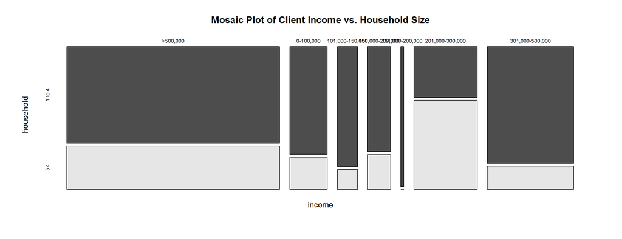

```r
mosaicplot(table(corr_data), main = "Mosaic Plot of Client Income vs. Household Size", color = TRUE)
```

# Bar chart for clients gross income

Data is in the column `Client_Income`

The values expected are

> <50,000

> 51,000-100,000

> 101,000-150,000

> 151,000-200,000

> 201,000-300,000

> 300,000-500,000

> 500,000<

```r
Income_Data = Patient_Data$Client_Income
```

### Check the data is clean

```r
as.data.frame(table(Patient_Data$Client_Income))
```

```
##              Var1 Freq
## 1         <50,000    5
## 2        >500,000   75
## 3 101,000-150,000    7
## 4 150,000-200,000    8
## 5 151,000-200,000    1
## 6 201,000-300,000   22
## 7 301,000-500,000   31
## 8  50,000-100,000    8
```

### Confirm

```r
as.data.frame(table(Patient_Data$Client_Income))
```

```
##              Var1 Freq
## 1         <50,000    5
## 2        >500,000   75
## 3 101,000-150,000    7
## 4 150,000-200,000    8
## 5 151,000-200,000    1
## 6 201,000-300,000   22
## 7 301,000-500,000   31
## 8  50,000-100,000    8
```

### Create plot data

```r
customer_income = as.data.frame(table(Patient_Data$Client_Income))
colnames(customer_income) = c("Income", "Frequency")
```

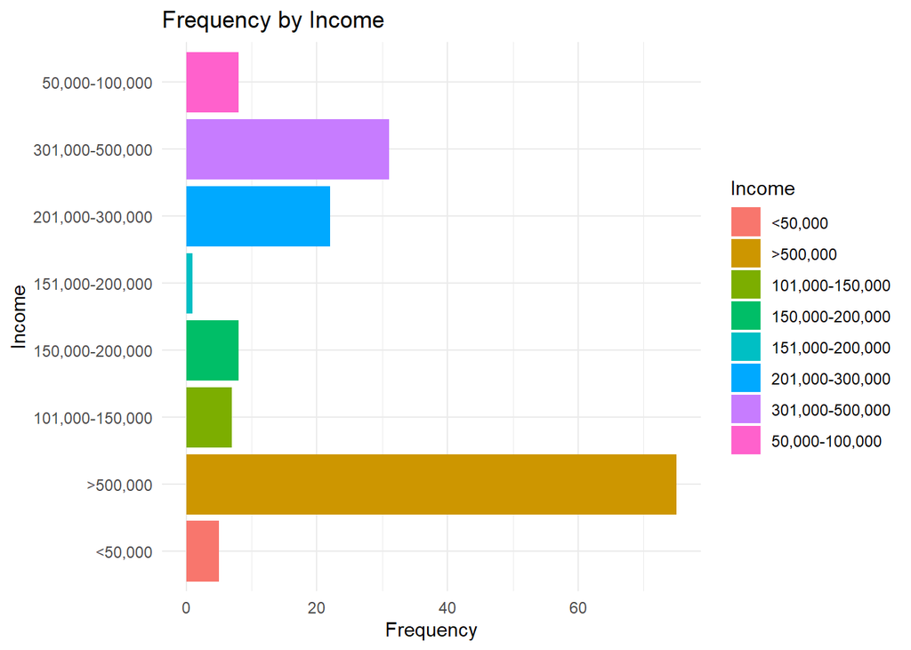

```r
create_frequency_bar_graphs(customer_income, "Income", "Frequency")
```

### Income by in-patient

```r
In_patient_Income = Patient_Data %>%
  filter(Facility_Type == "Inpatient") %>%
  .$Client_Income %>%
  table() %>%
  as.data.frame()


names(In_patient_Income) = c("Client_Income", "InPatient_Freq")
In_patient_Income
```

```
##     Client_Income InPatient_Freq
## 1         <50,000              1
## 2        >500,000              5
## 3 101,000-150,000              1
## 4 150,000-200,000              2
## 5 151,000-200,000              1
## 6 201,000-300,000              4
## 7 301,000-500,000              3
```

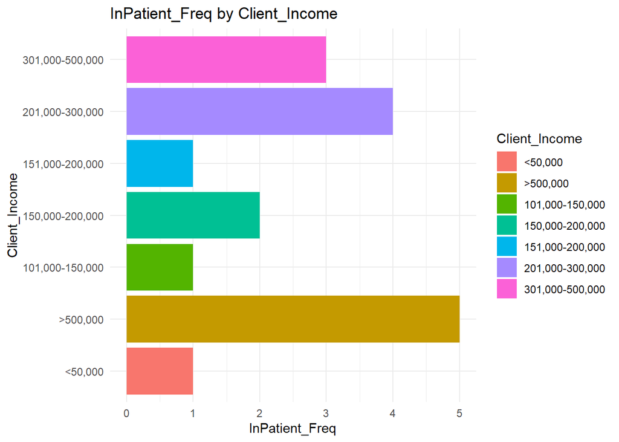

```r
create_frequency_bar_graphs(In_patient_Income, "Client_Income", "InPatient_Freq")
```

### Income by home-care

```r
HomeCare_Income = Patient_Data %>%
  filter(Facility_Type == "Home-care") %>%
  .$Client_Income %>%
  table() %>%
  as.data.frame()


names(HomeCare_Income) = c("Client_Income", "HomeCare_Freq")
HomeCare_Income
```

```
##     Client_Income HomeCare_Freq
## 1         <50,000             4
## 2        >500,000            70
## 3 101,000-150,000             6
## 4 150,000-200,000             6
## 5 201,000-300,000            18
## 6 301,000-500,000            28
## 7  50,000-100,000             8
```

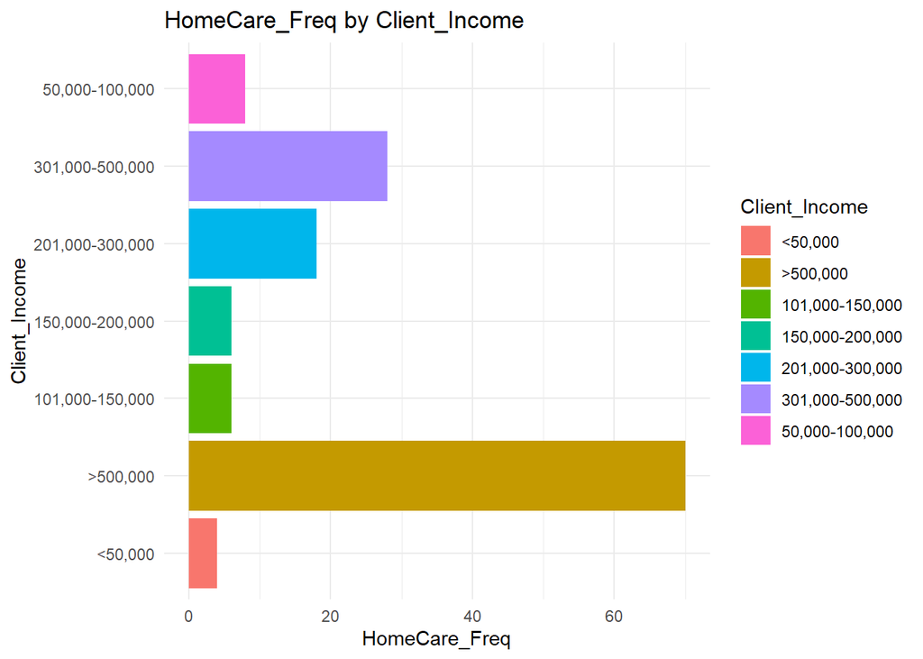

```r
create_frequency_bar_graphs(HomeCare_Income, "Client_Income", "HomeCare_Freq")
```

# Univariate regression for

## 1. Client Income

```r
Patient_Data <- Patient_Data %>%
  mutate(
    income_gt_500000 = as.integer(Client_Income == ">500,000"),
    income_301000_500000 = as.integer(Client_Income == "301,000-500,000"),
    income_101000_150000 = as.integer(Client_Income == "101,000-150,000"),
    income_150000_200000 = as.integer(Client_Income == "150,000-200,000"),
    income_lt_50000 = as.integer(Client_Income == "<50,000"),
    income_201000_300000 = as.integer(Client_Income == "201,000-300,000"),
    income_151000_200000 = as.integer(Client_Income == "151,000-200,000")
  )
```

### Cox regression

```r
income_cols = c("income_gt_500000", "income_301000_500000", "income_101000_150000", "income_150000_200000", "income_lt_50000", "income_201000_300000", "income_151000_200000")

for(column in income_cols){
  # filtered_data = Patient_Data %>% filter(Facility_Type == "Inpatient")
  print(paste("Inpatient cox regression for: ", column))
  cat("\n\n\n")
  print(cox_regression(Patient_Data, column))
  cat("\n\n\n")
}
```

```
## [1] "Inpatient cox regression for:  income_gt_500000"
##
##
##
## Call:
## coxph(formula = form, data = data)
##
##   n= 157, number of events= 47
##    (30 observations deleted due to missingness)
##
##                    coef exp(coef) se(coef)     z Pr(>|z|)
## income_gt_500000 0.2214    1.2478   0.2956 0.749    0.454
##
##                  exp(coef) exp(-coef) lower .95 upper .95
## income_gt_500000     1.248     0.8014    0.6991     2.227
##
## Concordance= 0.55  (se = 0.039 )
## Likelihood ratio test= 0.56  on 1 df,   p=0.5
## Wald test            = 0.56  on 1 df,   p=0.5
## Score (logrank) test = 0.56  on 1 df,   p=0.5
##
##
##
##
## [1] "Inpatient cox regression for:  income_301000_500000"
##
##
##
## Call:
## coxph(formula = form, data = data)
##
##   n= 157, number of events= 47
##    (30 observations deleted due to missingness)
##
##                        coef exp(coef) se(coef)     z Pr(>|z|)
## income_301000_500000 0.1742    1.1903   0.3581 0.486    0.627
##
##                      exp(coef) exp(-coef) lower .95 upper .95
## income_301000_500000      1.19     0.8401    0.5899     2.402
##
```

[output cut: 42 more lines]

```
##                         coef exp(coef) se(coef)      z Pr(>|z|)
## income_150000_200000 -1.1695    0.3105   1.0124 -1.155    0.248
##
##                      exp(coef) exp(-coef) lower .95 upper .95
## income_150000_200000    0.3105       3.22   0.04269     2.259
##
## Concordance= 0.513  (se = 0.019 )
## Likelihood ratio test= 1.99  on 1 df,   p=0.2
## Wald test            = 1.33  on 1 df,   p=0.2
## Score (logrank) test = 1.49  on 1 df,   p=0.2
##
##
##
##
## [1] "Inpatient cox regression for:  income_lt_50000"
```

```
## Call:
## coxph(formula = form, data = data)
##
##   n= 157, number of events= 47
##    (30 observations deleted due to missingness)
##
##                       coef  exp(coef)   se(coef)      z Pr(>|z|)
## income_lt_50000 -1.706e+01  3.890e-08  3.862e+03 -0.004    0.996
##
##                 exp(coef) exp(-coef) lower .95 upper .95
## income_lt_50000  3.89e-08   25706067         0       Inf
##
## Concordance= 0.519  (se = 0.008 )
## Likelihood ratio test= 3.38  on 1 df,   p=0.07
## Wald test            = 0  on 1 df,   p=1
## Score (logrank) test = 1.72  on 1 df,   p=0.2
##
##
##
##
## [1] "Inpatient cox regression for:  income_201000_300000"
##
##
##
## Call:
## coxph(formula = form, data = data)
##
##   n= 157, number of events= 47
##    (30 observations deleted due to missingness)
##
##                        coef exp(coef) se(coef)     z Pr(>|z|)
## income_201000_300000 0.4471    1.5638   0.3582 1.248    0.212
##
##                      exp(coef) exp(-coef) lower .95 upper .95
## income_201000_300000     1.564     0.6395    0.7749     3.156
##
## Concordance= 0.513  (se = 0.026 )
## Likelihood ratio test= 1.43  on 1 df,   p=0.2
## Wald test            = 1.56  on 1 df,   p=0.2
## Score (logrank) test = 1.58  on 1 df,   p=0.2
##
##
##
##
## [1] "Inpatient cox regression for:  income_151000_200000"
```

```
## Call:
## coxph(formula = form, data = data)
##
##   n= 157, number of events= 47
##    (30 observations deleted due to missingness)
##
##                            coef  exp(coef)   se(coef)      z Pr(>|z|)
## income_151000_200000 -1.602e+01  1.098e-07  4.190e+03 -0.004    0.997
##
##                      exp(coef) exp(-coef) lower .95 upper .95
## income_151000_200000 1.098e-07    9103428         0       Inf
##
## Concordance= 0.505  (se = 0.005 )
## Likelihood ratio test= 1.03  on 1 df,   p=0.3
## Wald test            = 0  on 1 df,   p=1
## Score (logrank) test = 0.52  on 1 df,   p=0.5
```

### Home-care

```r
for(column in income_cols){
  filtered_data = Patient_Data %>% filter(Facility_Type != "Inpatient")
  print(paste("Home-care cox regression for: ", column))
  cat("\n\n\n")
  print(cox_regression(filtered_data, column))
  cat("\n\n\n")
}
```

```
## [1] "Home-care cox regression for:  income_gt_500000"
##
##
##
## Call:
## coxph(formula = form, data = data)
##
##   n= 140, number of events= 36
##    (27 observations deleted due to missingness)
##
##                    coef exp(coef) se(coef)     z Pr(>|z|)
## income_gt_500000 0.4207    1.5230   0.3423 1.229    0.219
##
##                  exp(coef) exp(-coef) lower .95 upper .95
## income_gt_500000     1.523     0.6566    0.7786     2.979
##
## Concordance= 0.575  (se = 0.043 )
## Likelihood ratio test= 1.53  on 1 df,   p=0.2
## Wald test            = 1.51  on 1 df,   p=0.2
## Score (logrank) test = 1.53  on 1 df,   p=0.2
##
##
##
##
## [1] "Home-care cox regression for:  income_301000_500000"
##
##
##
## Call:
## coxph(formula = form, data = data)
##
##   n= 140, number of events= 36
##    (27 observations deleted due to missingness)
##
##                        coef exp(coef) se(coef)     z Pr(>|z|)
## income_301000_500000 0.1743    1.1905   0.4030 0.433    0.665
##
##                      exp(coef) exp(-coef) lower .95 upper .95
## income_301000_500000      1.19       0.84    0.5404     2.622
##
## Concordance= 0.496  (se = 0.033 )
## Likelihood ratio test= 0.18  on 1 df,   p=0.7
## Wald test            = 0.19  on 1 df,   p=0.7
## Score (logrank) test = 0.19  on 1 df,   p=0.7
##
##
##
##
## [1] "Home-care cox regression for:  income_101000_150000"
```

```
## Call:
## coxph(formula = form, data = data)
##
##   n= 140, number of events= 36
##    (27 observations deleted due to missingness)
##
##                            coef  exp(coef)   se(coef)      z Pr(>|z|)
## income_101000_150000 -1.708e+01  3.824e-08  3.933e+03 -0.004    0.997
##
##                      exp(coef) exp(-coef) lower .95 upper .95
## income_101000_150000 3.824e-08   26150554         0       Inf
##
## Concordance= 0.523  (se = 0.01 )
## Likelihood ratio test= 3.3  on 1 df,   p=0.07
## Wald test            = 0  on 1 df,   p=1
## Score (logrank) test = 1.69  on 1 df,   p=0.2
##
##
##
##
## [1] "Home-care cox regression for:  income_150000_200000"
```

```
## Call:
## coxph(formula = form, data = data)
##
##   n= 140, number of events= 36
##    (27 observations deleted due to missingness)
##
##                            coef  exp(coef)   se(coef)      z Pr(>|z|)
## income_150000_200000 -1.711e+01  3.712e-08  3.460e+03 -0.005    0.996
##
##                      exp(coef) exp(-coef) lower .95 upper .95
## income_150000_200000 3.712e-08   26940819         0       Inf
##
## Concordance= 0.527  (se = 0.011 )
## Likelihood ratio test= 4.35  on 1 df,   p=0.04
## Wald test            = 0  on 1 df,   p=1
## Score (logrank) test = 2.25  on 1 df,   p=0.1
##
##
##
##
## [1] "Home-care cox regression for:  income_lt_50000"
```

```
## Call:
## coxph(formula = form, data = data)
##
##   n= 140, number of events= 36
##    (27 observations deleted due to missingness)
##
##                       coef  exp(coef)   se(coef)      z Pr(>|z|)
## income_lt_50000 -1.705e+01  3.927e-08  4.828e+03 -0.004    0.997
##
##                 exp(coef) exp(-coef) lower .95 upper .95
## income_lt_50000 3.927e-08   25465445         0       Inf
##
## Concordance= 0.516  (se = 0.008 )
## Likelihood ratio test= 2.15  on 1 df,   p=0.1
## Wald test            = 0  on 1 df,   p=1
## Score (logrank) test = 1.09  on 1 df,   p=0.3
##
##
##
##
## [1] "Home-care cox regression for:  income_201000_300000"
##
##
##
## Call:
## coxph(formula = form, data = data)
##
##   n= 140, number of events= 36
##    (27 observations deleted due to missingness)
##
##                        coef exp(coef) se(coef)     z Pr(>|z|)
## income_201000_300000 0.2503    1.2845   0.4492 0.557    0.577
##
##                      exp(coef) exp(-coef) lower .95 upper .95
## income_201000_300000     1.284     0.7785    0.5326     3.098
##
## Concordance= 0.504  (se = 0.028 )
## Likelihood ratio test= 0.29  on 1 df,   p=0.6
## Wald test            = 0.31  on 1 df,   p=0.6
## Score (logrank) test = 0.31  on 1 df,   p=0.6
```

[output cut: 9 more lines]

```
## coxph(formula = form, data = data)
##
##   n= 140, number of events= 36
##    (27 observations deleted due to missingness)
##
##                      coef exp(coef) se(coef)  z Pr(>|z|)
## income_151000_200000   NA        NA        0 NA       NA
##
##                      exp(coef) exp(-coef) lower .95 upper .95
## income_151000_200000        NA         NA        NA        NA
##
## Concordance= 0.5  (se = 0 )
## Likelihood ratio test= 0  on 0 df,   p=1
## Wald test            = NA  on 0 df,   p=NA
## Score (logrank) test = 0  on 0 df,   p=1
```

### In-patient

```r
for(column in income_cols){
  filtered_data = Patient_Data %>% filter(Facility_Type == "Inpatient")
  print(paste("Inpatient cox regression for: ", column))
  cat("\n\n\n")
  print(cox_regression(filtered_data, column))
  cat("\n\n\n")
}
```

```
## [1] "Inpatient cox regression for:  income_gt_500000"
##
##
##
## Call:
## coxph(formula = form, data = data)
##
##   n= 17, number of events= 11
##    (3 observations deleted due to missingness)
##
##                     coef exp(coef) se(coef)      z Pr(>|z|)
## income_gt_500000 -0.1030    0.9021   0.6806 -0.151     0.88
##
##                  exp(coef) exp(-coef) lower .95 upper .95
## income_gt_500000    0.9021      1.109    0.2377     3.424
##
## Concordance= 0.505  (se = 0.081 )
## Likelihood ratio test= 0.02  on 1 df,   p=0.9
## Wald test            = 0.02  on 1 df,   p=0.9
## Score (logrank) test = 0.02  on 1 df,   p=0.9
##
##
##
##
## [1] "Inpatient cox regression for:  income_301000_500000"
##
##
##
## Call:
## coxph(formula = form, data = data)
##
##   n= 17, number of events= 11
##    (3 observations deleted due to missingness)
##
##                        coef exp(coef) se(coef)     z Pr(>|z|)
## income_301000_500000 0.7126    2.0393   0.8436 0.845    0.398
##
##                      exp(coef) exp(-coef) lower .95 upper .95
## income_301000_500000     2.039     0.4904    0.3903     10.65
##
```

[output cut: 42 more lines]

```
##                         coef exp(coef) se(coef)      z Pr(>|z|)
## income_150000_200000 -0.3353    0.7152   1.0624 -0.316    0.752
##
##                      exp(coef) exp(-coef) lower .95 upper .95
## income_150000_200000    0.7152      1.398   0.08913     5.738
##
## Concordance= 0.477  (se = 0.084 )
## Likelihood ratio test= 0.11  on 1 df,   p=0.7
## Wald test            = 0.1  on 1 df,   p=0.8
## Score (logrank) test = 0.1  on 1 df,   p=0.8
##
##
##
##
## [1] "Inpatient cox regression for:  income_lt_50000"
```

```
## Call:
## coxph(formula = form, data = data)
##
##   n= 17, number of events= 11
##    (3 observations deleted due to missingness)
##
##                       coef  exp(coef)   se(coef)      z Pr(>|z|)
## income_lt_50000 -1.813e+01  1.341e-08  1.151e+04 -0.002    0.999
##
##                 exp(coef) exp(-coef) lower .95 upper .95
## income_lt_50000 1.341e-08   74547460         0       Inf
##
## Concordance= 0.533  (se = 0.032 )
## Likelihood ratio test= 1.08  on 1 df,   p=0.3
## Wald test            = 0  on 1 df,   p=1
## Score (logrank) test = 0.56  on 1 df,   p=0.5
##
##
##
##
## [1] "Inpatient cox regression for:  income_201000_300000"
##
##
##
## Call:
## coxph(formula = form, data = data)
##
##   n= 17, number of events= 11
##    (3 observations deleted due to missingness)
##
##                        coef exp(coef) se(coef)     z Pr(>|z|)
## income_201000_300000 0.5112    1.6674   0.6295 0.812    0.417
##
##                      exp(coef) exp(-coef) lower .95 upper .95
## income_201000_300000     1.667     0.5997    0.4855     5.726
##
## Concordance= 0.523  (se = 0.068 )
## Likelihood ratio test= 0.62  on 1 df,   p=0.4
## Wald test            = 0.66  on 1 df,   p=0.4
## Score (logrank) test = 0.67  on 1 df,   p=0.4
##
##
##
##
## [1] "Inpatient cox regression for:  income_151000_200000"
```

```
## Call:
## coxph(formula = form, data = data)
##
##   n= 17, number of events= 11
##    (3 observations deleted due to missingness)
##
##                            coef  exp(coef)   se(coef)      z Pr(>|z|)
## income_151000_200000 -1.926e+01  4.303e-09  1.239e+04 -0.002    0.999
##
##                      exp(coef) exp(-coef) lower .95 upper .95
## income_151000_200000 4.303e-09  232388322         0       Inf
##
## Concordance= 0.551  (se = 0.048 )
## Likelihood ratio test= 2.78  on 1 df,   p=0.1
## Wald test            = 0  on 1 df,   p=1
## Score (logrank) test = 1.5  on 1 df,   p=0.2
```

# Bar chart (When it was suggested that the patient requires a caregiver, what was your reaction)

Data is in the column `Initial_Reaction`

The values expected are

> Happy

> In different

> Didn’t like it at all

> Was Forced

```r
as.data.frame(table(Patient_Data$Initial_Reaction))
```

```
##             Var1 Freq
## 1 Didn’t Like it    8
## 2          Happy  148
## 3   In different   27
## 4     Was forced    2
```

### Plot data

```r
initial_reaction = as.data.frame(table(Patient_Data$Initial_Reaction))
colnames(initial_reaction) = c("Client_Reaction", "Frequency")
initial_reaction
```

```
##   Client_Reaction Frequency
## 1  Didn’t Like it         8
## 2           Happy       148
## 3    In different        27
## 4      Was forced         2
```

### Plot

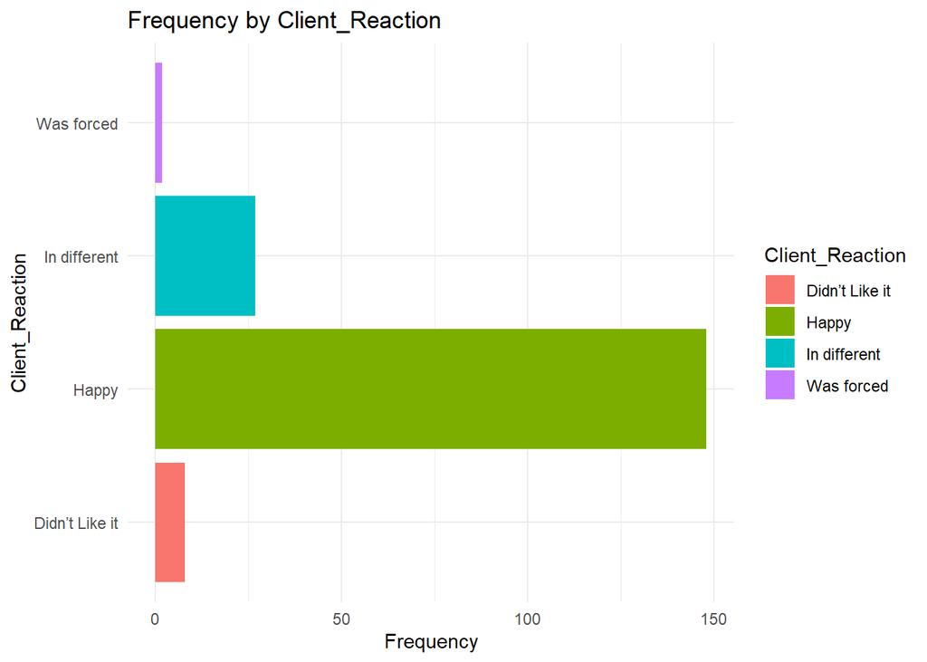

```r
create_frequency_bar_graphs(initial_reaction,"Client_Reaction", "Frequency" )
```

### Initial reaction by homecare

```r
HomeCare_Initial_Reaction = Patient_Data %>%
  filter(Facility_Type == "Home-care") %>%
  .$Initial_Reaction %>%
  table() %>%
  as.data.frame()


names(HomeCare_Initial_Reaction) = c("Client_Initial_Reaction", "HomeCare_Freq")
HomeCare_Initial_Reaction
```

```
##   Client_Initial_Reaction HomeCare_Freq
## 1          Didn’t Like it             8
## 2                   Happy           129
## 3            In different            26
## 4              Was forced             2
```

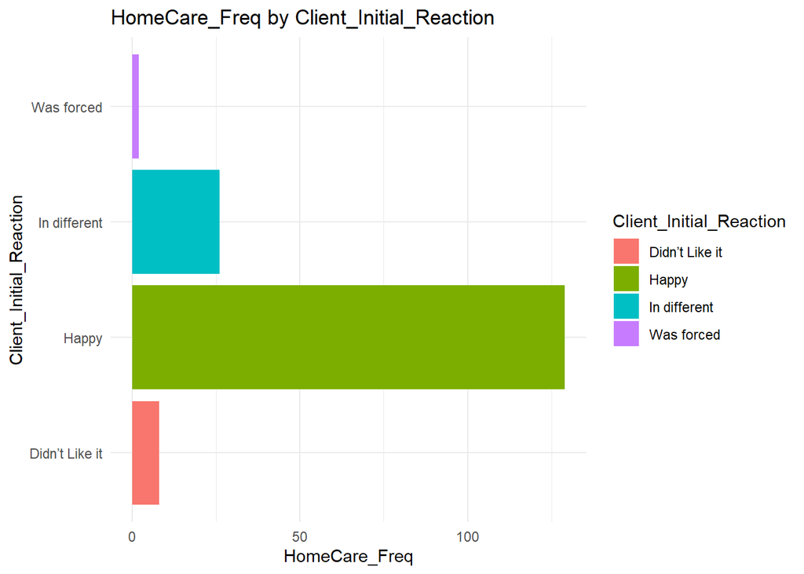

```r
create_frequency_bar_graphs(HomeCare_Initial_Reaction, "Client_Initial_Reaction", "HomeCare_Freq")
```

### Initial reaction by inpatient

```r
Inpatient_Initial_Reaction = Patient_Data %>%
  filter(Facility_Type == "Inpatient") %>%
  .$Initial_Reaction %>%
  table() %>%
  as.data.frame()


names(Inpatient_Initial_Reaction) = c("Client_Initial_Reaction", "Inpatient_Freq")
Inpatient_Initial_Reaction
```

```
##   Client_Initial_Reaction Inpatient_Freq
## 1                   Happy             19
## 2            In different              1
```

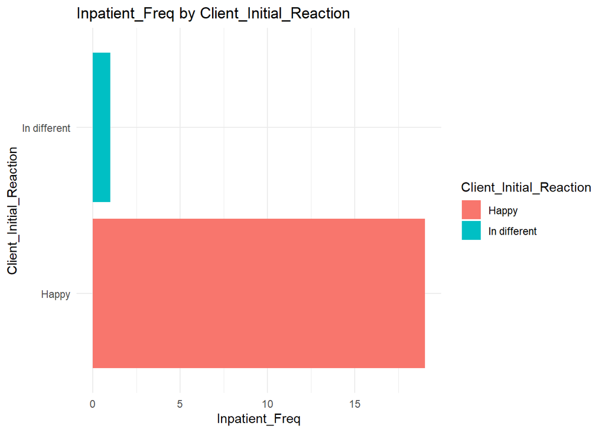

```r
create_frequency_bar_graphs(Inpatient_Initial_Reaction, "Client_Initial_Reaction", "Inpatient_Freq")
```

# Bar chart (%) Q47. what is your most preferred care arrangement

Data is in the column `Preferred_care`

The values expected are

> Homecare under a family member/relative

> Homecare provided by a healthcare provider

> Hospital setting

> Step down facility like Care 360

> Other

```r
as.data.frame(table(Patient_Data$Preferred_Care))
```

```
##                                         Var1 Freq
## 1     Any other facility that offer homecare    1
## 2 Homecare provided by a Healthcare Provider    1
## 3 Homecare Provided by a Healthcare Provider  116
## 4         Homecare Provided by family member    1
## 5             Homecare under a family member   10
## 6                           Hospital Setting    6
## 7                         Step down Facility   49
```

combine

> Homecare Provided by a Healthcare Provider -> Homecare provided by a Healthcare Provider

> Homecare Provided by family member -> Homecare under a family member

```r
Patient_Data = Patient_Data %>%
  mutate(Preferred_Care = str_replace_all(Preferred_Care, "Homecare provided by a Healthcare Provider", "Homecare Provided by a Healthcare Provider"),
         Preferred_Care = str_replace_all(Preferred_Care, "Homecare Provided by family member", "Homecare under a family member")
         )
```

### Confirm

```r
as.data.frame(table(Patient_Data$Preferred_Care))
```

```
##                                         Var1 Freq
## 1     Any other facility that offer homecare    1
## 2 Homecare Provided by a Healthcare Provider  117
## 3             Homecare under a family member   11
## 4                           Hospital Setting    6
## 5                         Step down Facility   49
```

### plot data

```r
preferred_care = as.data.frame(table(Patient_Data$Preferred_Care))
colnames(preferred_care) = c("preferred_care", "frequency")
preferred_care$percentage = preferred_care$frequency/ sum(preferred_care$frequency) * 100
preferred_care
```

```
##                               preferred_care frequency percentage
## 1     Any other facility that offer homecare         1  0.5434783
## 2 Homecare Provided by a Healthcare Provider       117 63.5869565
## 3             Homecare under a family member        11  5.9782609
## 4                           Hospital Setting         6  3.2608696
## 5                         Step down Facility        49 26.6304348
```

### Plot

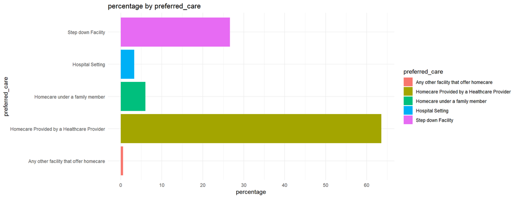

```r
create_percentage_bar_graphs(preferred_care, "preferred_care", "percentage")
```

### Preferred care for inpatient

```r
Inpatient_Preferred_Care = Patient_Data %>%
  filter(Facility_Type == "Inpatient") %>%
  .$Preferred_Care %>%
  table() %>%
  as.data.frame()
colnames(Inpatient_Preferred_Care) = c("preferred_care", "frequency")
Inpatient_Preferred_Care$Inpatient_percentage = Inpatient_Preferred_Care$frequency/ sum(Inpatient_Preferred_Care$frequency) * 100


Inpatient_Preferred_Care
```

```
##                               preferred_care frequency Inpatient_percentage
## 1 Homecare Provided by a Healthcare Provider         1                    5
## 2             Homecare under a family member         1                    5
## 3                           Hospital Setting         1                    5
## 4                         Step down Facility        17                   85
```

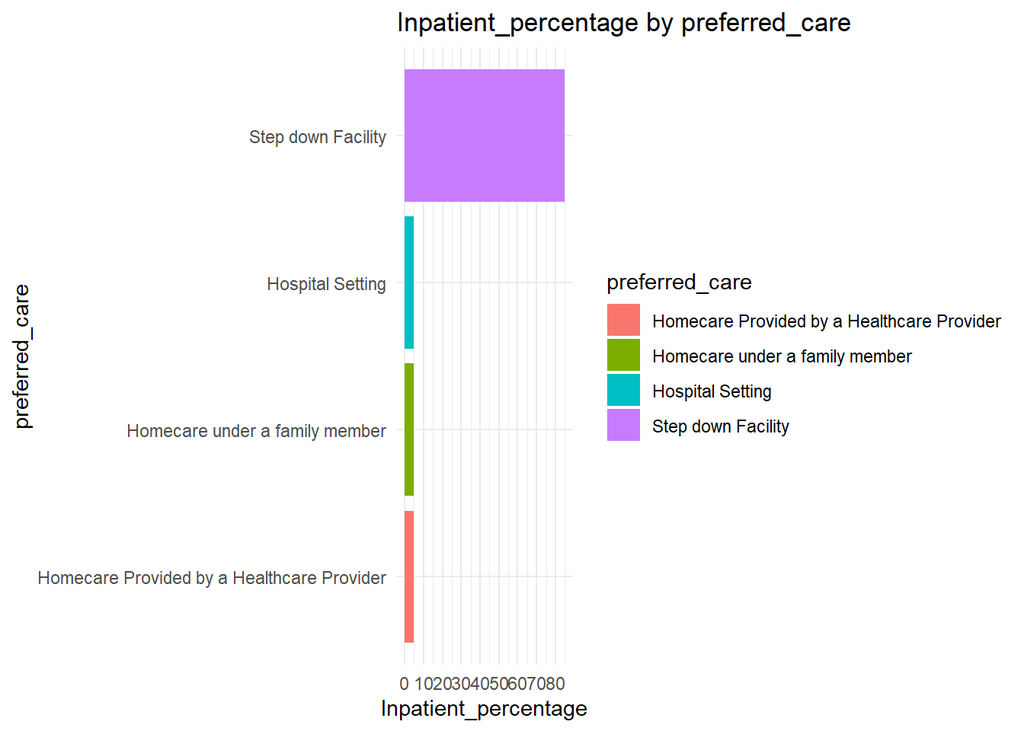

```r
create_percentage_bar_graphs(Inpatient_Preferred_Care, "preferred_care", "Inpatient_percentage")
```

### preferred care by Homecare

```r
HomeCare_Preferred_Care = Patient_Data %>%
  filter(Facility_Type == "Home-care") %>%
  .$Preferred_Care %>%
  table() %>%
  as.data.frame()
colnames(HomeCare_Preferred_Care) = c("preferred_care", "frequency")
HomeCare_Preferred_Care$HomeCare_percentage = HomeCare_Preferred_Care$frequency/ sum(HomeCare_Preferred_Care$frequency) * 100


HomeCare_Preferred_Care
```

```
##                               preferred_care frequency HomeCare_percentage
## 1     Any other facility that offer homecare         1           0.6097561
## 2 Homecare Provided by a Healthcare Provider       116          70.7317073
## 3             Homecare under a family member        10           6.0975610
## 4                           Hospital Setting         5           3.0487805
## 5                         Step down Facility        32          19.5121951
```

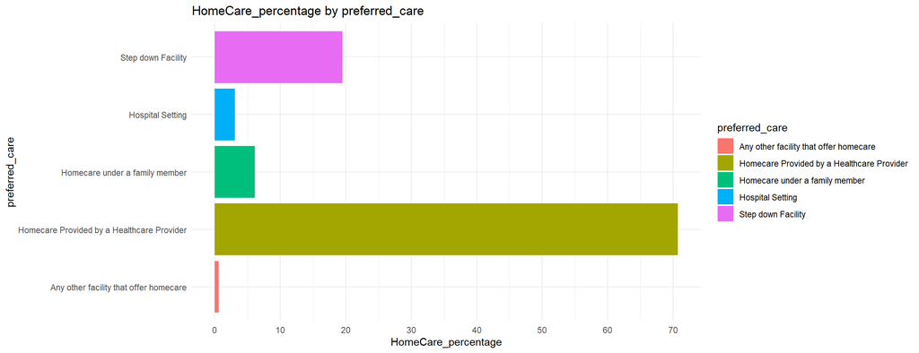

```r
create_percentage_bar_graphs(HomeCare_Preferred_Care, "preferred_care", "HomeCare_percentage")
```

# Bar chart type of shift taken

Data is in the column `Shift_Taken`

The values expected are

> 24 hours (Day and Night)

> Day

> Night

```r
as.data.frame(table(Patient_Data$Shift_Taken))
```

```
##            Var1 Freq
## 1           Day   32
## 2 Day and Night  109
## 3            NA   19
## 4         Night   23
```

### plot data

```r
shift_taken = as.data.frame(table(Patient_Data$Shift_Taken))
colnames(shift_taken) = c("shift", "frequency")

shift_taken = shift_taken[shift_taken$shift %in% as.factor(c("Day", "Day and Night", "Night")),]
shift_taken
```

```
##           shift frequency
## 1           Day        32
## 2 Day and Night       109
## 4         Night        23
```

### Plot

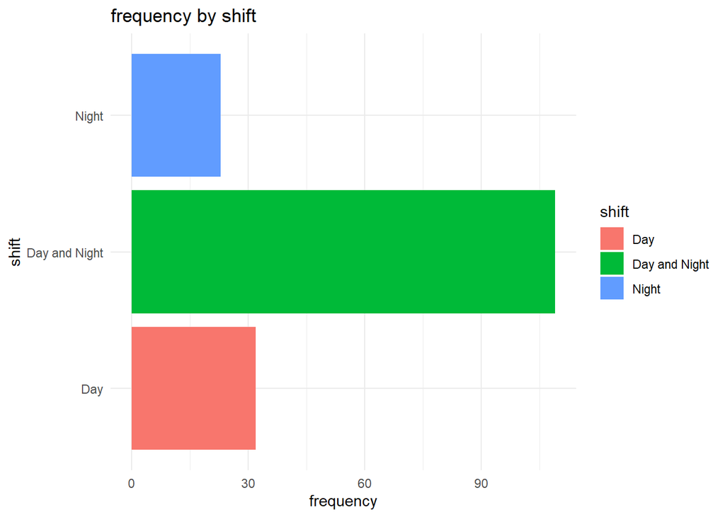

```r
create_frequency_bar_graphs(shift_taken,"shift", "frequency" )
```

### Shift by Homecare

```r
HomeCare_shift_taken = Patient_Data %>%
  filter(Facility_Type == "Home-care") %>%
  .$Shift_Taken %>%
  table() %>%
  as.data.frame()
colnames(HomeCare_shift_taken) = c("shift_taken", "frequency")



HomeCare_shift_taken
```

```
##     shift_taken frequency
## 1           Day        32
## 2 Day and Night       109
## 3         Night        23
```

```r
InPatient_shift_taken = Patient_Data %>%
  filter(Facility_Type == "Inpatient") %>%
  .$Shift_Taken %>%
  table() %>%
  as.data.frame()
colnames(InPatient_shift_taken) = c("shift_taken", "frequency")



InPatient_shift_taken
```

```
##   shift_taken frequency
## 1          NA        19
```

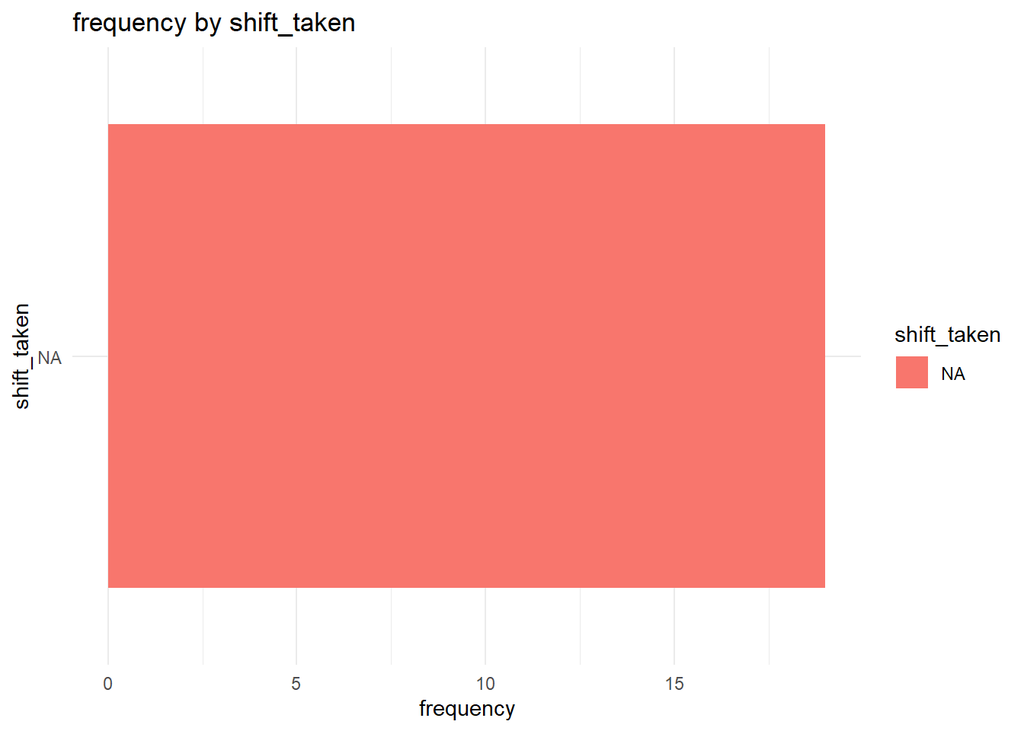

```r
create_frequency_bar_graphs(InPatient_shift_taken, "shift_taken", "frequency")
```